# LIMPIEZA DE DATOS - RECLUTAMIENTO (VERDATA R3)

Edward Bonilla, Juana Bello

2026-11-18

# LIMPIEZA DE DATOS

Aplicamos la cadena de análisis vista en la **Clase 1** (exploración, faltantes, duplicados, texto, inconsistencias, atípicos, estandarización, normalización y exportación) a la base de **reclutamiento (Verdata, réplica R3)**.

```r
list.files("../Datos") # Visualizo archivos de la carpeta
```

```
## [1] "verdata-reclutamiento-R3.csv"
```

```r
data <- read.csv("E:/Mis Documentos/Desktop/ESPECIALIZA AI/datos/ACTIVIDAD 1/ACTIVIDAD-1-CIENCIA-DE-DATOS-/DATOS/verdata-reclutamiento-R3.csv", fileEncoding = "UTF-8")
```

Visualizamos los datos

```r
data
```

## Diccionario de variables

| Variable | Descripción |
| --- | --- |
| `replica` | Réplica de los datos (constante: “R3”) |
| `match_group_id` | Identificador único del caso (hash) |
| `in_1` … `in_34` | Indicadoras 0/1: presencia del caso en cada una de las 34 fuentes |
| `edad_categoria` | Edad en quinquenios (0-4, 5-9, …, 95+) |
| `edad_jep` | Ciclo de vida: Infancia / Adolescencia / Adultez |
| `etnia` | Mestizo, Indígena, NARP, ROM |
| `sexo` | Hombre / Mujer |
| `p_str` | Presunto responsable (GUE-FARC, GUE-ELN, GUE-OTRO, PARA, EST, OTRO, múltiple) |
| `dept_code_hecho`, `muni_code_hecho` | Códigos DIVIPOLA del departamento y municipio del hecho |
| `yy_hecho`, `yymm_hecho` | Año y año-mes del hecho |
| `is_conflict` | Indicadora de hecho en el marco del conflicto |
| `*_imputed` | Indicadoras de si el valor de esa variable fue imputado |

## Exploración de los datos

```r
head(data)
```

```
##   replica                           match_group_id in_1 in_2 in_3 in_4 in_5
## 1      R3 00052edf411572e2a50685391d81775cec67f186    0    0    0    0    0
## 2      R3 00070241835c406320a12aa1a6dbd8f9bdc30f33    1    0    0    0    0
## 3      R3 00076cb32b97cfa506dc09020980c78b4fca8570    1    0    0    0    0
## 4      R3 0007b2badad2cf9403a3bbef5ef9d59fe2b07e97    1    0    0    0    0
## 5      R3 001db4a364495077b9e9ff13a38e2b8008eff743    0    0    0    0    0
## 6      R3 0025f6385d77feca6cbfa08971cd0c7b56869bab    0    0    0    0    0
##   in_6 in_7 in_8 in_9 in_10 in_11 in_12 in_13 in_14 in_15 in_16 in_17 in_18
## 1    0    0    0    0     0     0     0     0     0     0     0     0     0
## 2    0    0    0    0     0     0     0     0     0     0     0     0     0
## 3    0    0    0    0     0     0     0     0     0     0     0     0     0
## 4    0    0    0    0     0     0     0     0     0     0     0     1     0
## 5    0    0    0    0     0     0     0     0     0     0     0     1     0
## 6    0    0    0    0     0     0     0     0     0     0     0     0     0
##   in_19 in_20 in_21 in_22 in_23 in_24 in_25 in_26 in_27 in_28 in_29 in_30 in_31
```

[output cut: 34 more lines]

```r
tail(data)
```

```
##       replica                           match_group_id in_1 in_2 in_3 in_4 in_5
## 19221      R3 fedefc68fa4e5621f3620b224c7d301812476b25    0    0    0    0    0
## 19222      R3 feea3757ccf0091de7c087a88bc8e48b42b0d6b8    0    0    0    0    0
## 19223      R3 ff0d5450e0d8c89b874479ced8b603c5749c877f    0    0    0    0    0
## 19224      R3 ffc6bfff9afb137e18753046b3f54edd1ba5b89e    0    0    0    0    0
## 19225      R3 ffdbfc5174b4d34d0693451f92b60e9ce394b0c5    0    0    0    0    0
## 19226      R3 fff5764fa02980c15a97c20238c97a0e7b2226a1    0    0    0    0    0
##       in_6 in_7 in_8 in_9 in_10 in_11 in_12 in_13 in_14 in_15 in_16 in_17 in_18
## 19221    0    0    0    0     0     0     0     0     0     0     0     0     0
## 19222    0    0    0    0     0     0     0     0     0     0     0     0     0
## 19223    0    0    0    0     0     0     0     0     0     0     0     0     0
## 19224    0    0    0    0     0     0     0     0     0     0     0     0     0
## 19225    0    0    0    0     0     0     0     0     0     0     0     0     0
## 19226    0    0    0    0     0     0     0     0     0     0     0     0     0
##       in_19 in_20 in_21 in_22 in_23 in_24 in_25 in_26 in_27 in_28 in_29 in_30
```

[output cut: 41 more lines]

```r
dim(data)
```

```
## [1] 19226    53
```

```r
colnames(data)
```

```
##  [1] "replica"                 "match_group_id"
##  [3] "in_1"                    "in_2"
##  [5] "in_3"                    "in_4"
##  [7] "in_5"                    "in_6"
##  [9] "in_7"                    "in_8"
## [11] "in_9"                    "in_10"
## [13] "in_11"                   "in_12"
## [15] "in_13"                   "in_14"
## [17] "in_15"                   "in_16"
## [19] "in_17"                   "in_18"
## [21] "in_19"                   "in_20"
## [23] "in_21"                   "in_22"
## [25] "in_23"                   "in_24"
## [27] "in_25"                   "in_26"
## [29] "in_27"                   "in_28"
## [31] "in_29"                   "in_30"
## [33] "in_31"                   "in_32"
## [35] "in_33"                   "in_34"
## [37] "dept_code_hecho"         "edad_categoria"
## [39] "edad_categoria_imputed"  "edad_jep"
## [41] "edad_jep_imputed"        "etnia"
## [43] "etnia_imputed"           "is_conflict"
## [45] "is_conflict_imputed"     "muni_code_hecho"
## [47] "muni_code_hecho_imputed" "p_str"
## [49] "p_str_imputed"           "sexo"
## [51] "sexo_imputed"            "yy_hecho"
## [53] "yymm_hecho"
```

```r
str(data)
```

```
## 'data.frame':    19226 obs. of  53 variables:
##  $ replica                : chr  "R3" "R3" "R3" "R3" ...
##  $ match_group_id         : chr  "00052edf411572e2a50685391d81775cec67f186" "00070241835c406320a12aa1a6dbd8f9bdc30f33" "00076cb32b97cfa506dc09020980c78b4fca8570" "0007b2badad2cf9403a3bbef5ef9d59fe2b07e97" ...
##  $ in_1                   : int  0 1 1 1 0 0 0 1 1 0 ...
##  $ in_2                   : int  0 0 0 0 0 0 0 0 0 0 ...
##  $ in_3                   : int  0 0 0 0 0 0 0 0 0 0 ...
##  $ in_4                   : int  0 0 0 0 0 0 0 0 0 0 ...
##  $ in_5                   : int  0 0 0 0 0 0 0 0 0 0 ...
##  $ in_6                   : int  0 0 0 0 0 0 0 0 0 1 ...
##  $ in_7                   : int  0 0 0 0 0 0 0 0 0 0 ...
##  $ in_8                   : int  0 0 0 0 0 0 0 0 0 0 ...
##  $ in_9                   : int  0 0 0 0 0 0 0 0 0 0 ...
##  $ in_10                  : int  0 0 0 0 0 0 0 0 0 0 ...
##  $ in_11                  : int  0 0 0 0 0 0 0 0 0 0 ...
##  $ in_12                  : int  0 0 0 0 0 0 0 0 0 0 ...
```

[output cut: 39 more lines]

### Variables derivadas

Para poder aplicar el análisis cuantitativo de la clase (que usó Ingreso, Edad e Hijos) construimos variables numéricas a partir de las existentes:

- `n_fuentes`: número de fuentes en las que aparece el caso (suma de `in_1` a `in_34`).
- `edad_aprox`: punto medio de cada categoría de edad (aproximación; para “95+” se usa 95).
- `mes_hecho`: mes extraído de `yymm_hecho`.
- `departamento`: nombre del departamento a partir del código DIVIPOLA.

```r
# Número de fuentes por caso
data$n_fuentes <- rowSums(data[ , paste0("in_", 1:34)])

# Edad aproximada (punto medio de la categoría)
edad_puntos <- c("0-4" = 2, "5-9" = 7, "10-14" = 12, "15-19" = 17,
                 "20-24" = 22, "25-29" = 27, "30-34" = 32, "35-39" = 37,
                 "40-44" = 42, "45-49" = 47, "50-54" = 52, "55-59" = 57,
                 "60-64" = 62, "65-69" = 67, "70-74" = 72, "75-79" = 77,
                 "80-84" = 82, "85-89" = 87, "90-94" = 92, "95+" = 95)
data$edad_aprox <- unname(edad_puntos[data$edad_categoria])

# Mes del hecho
data$mes_hecho <- data$yymm_hecho %% 100

# Nombre del departamento (códigos DIVIPOLA)
dept_nombres <- c("5" = "Antioquia", "8" = "Atlántico", "11" = "Bogotá D.C.",
                  "13" = "Bolívar", "15" = "Boyacá", "17" = "Caldas",
                  "18" = "Caquetá", "19" = "Cauca", "20" = "Cesar",
                  "23" = "Córdoba", "25" = "Cundinamarca", "27" = "Chocó",
                  "41" = "Huila", "44" = "La Guajira", "47" = "Magdalena",
                  "50" = "Meta", "52" = "Nariño", "54" = "Norte de Santander",
                  "63" = "Quindío", "66" = "Risaralda", "68" = "Santander",
                  "70" = "Sucre", "73" = "Tolima", "76" = "Valle del Cauca",
                  "81" = "Arauca", "85" = "Casanare", "86" = "Putumayo",
                  "88" = "San Andrés", "91" = "Amazonas", "94" = "Guainía",
                  "95" = "Guaviare", "97" = "Vaupés", "99" = "Vichada")
data$departamento <- unname(dept_nombres[as.character(data$dept_code_hecho)])
```

```r
# Función para tablas de frecuencia (frecuencia absoluta y porcentaje)
tabla_freq <- function(x, nombre) {
  tab <- data.frame(sort(table(x), decreasing = TRUE))
  colnames(tab) <- c(nombre, "Frecuencia")
  tab$Porcentaje <- round(100 * tab$Frecuencia / sum(tab$Frecuencia), 1)
  tab
}
```

### ANALISIS DE SEXO

```r
tabla_Sexo <- tabla_freq(data$sexo, "Sexo")

tabla_Sexo
```

```
##     Sexo Frecuencia Porcentaje
## 1 HOMBRE      13423       69.8
## 2  MUJER       5803       30.2
```

**De un total de 19226 casos analizados ($n = 19226$), predomina el sexo hombre con 13423 casos, equivalente al 69.8% del total; el sexo mujer registra 5803 casos (30.2%).**

### ANALISIS DE ETNIA

```r
tabla_Etnia <- tabla_freq(data$etnia, "Etnia")

tabla_Etnia
```

```
##      Etnia Frecuencia Porcentaje
## 1  MESTIZO      15069       78.4
## 2 INDIGENA       2268       11.8
## 3     NARP       1880        9.8
## 4      ROM          9        0.0
```

**De un total de 19226 casos, la categoría predominante es mestizo con 15069 casos (78.4%). En segundo lugar se ubica indigena (11.8%), seguida de narp (9.8%). La categoría con menor participación es rom con 9 casos.**

### ANALISIS DEL PRESUNTO RESPONSABLE

```r
tabla_Responsable <- tabla_freq(data$p_str, "Presunto_Responsable")

tabla_Responsable
```

```
##   Presunto_Responsable Frecuencia Porcentaje
## 1             GUE-FARC      14777       76.9
## 2                 PARA       2194       11.4
## 3              GUE-ELN       1440        7.5
## 4             multiple        396        2.1
## 5                 OTRO        194        1.0
## 6             GUE-OTRO        139        0.7
## 7                  EST         86        0.4
```

**El presunto responsable más frecuente es GUE-FARC con 14777 casos (76.9%), seguido de PARA (11.4%) y GUE-ELN (7.5%). Se observa además que la categoría `multiple` está escrita en minúscula mientras las demás van en mayúscula: una inconsistencia de formato que se corrige en la limpieza de texto.**

### ANALISIS DEL CICLO DE VIDA (EDAD JEP)

```r
tabla_Edad_JEP <- tabla_freq(data$edad_jep, "Ciclo_Vida")

tabla_Edad_JEP
```

```
##     Ciclo_Vida Frecuencia Porcentaje
## 1 ADOLESCENCIA       9140       47.5
## 2     INFANCIA       7248       37.7
## 3      ADULTEZ       2838       14.8
```

**La categoría predominante es adolescencia con 9140 casos (47.5%), seguida de infancia (37.7%) y adultez (14.8%).**

### ANALISIS DE LA CATEGORÍA DE EDAD

```r
tabla_Edad_Cat <- tabla_freq(data$edad_categoria, "Edad_Categoria")

tabla_Edad_Cat
```

```
##    Edad_Categoria Frecuencia Porcentaje
## 1           15-19      10159       52.8
## 2           10-14       6095       31.7
## 3             0-4        762        4.0
## 4           20-24        754        3.9
## 5             5-9        391        2.0
## 6           25-29        375        2.0
## 7           30-34        195        1.0
## 8           40-44        148        0.8
## 9           35-39         86        0.4
## 10          90-94         74        0.4
## 11            95+         72        0.4
## 12          45-49         44        0.2
## 13          50-54         30        0.2
## 14          55-59         18        0.1
## 15          60-64         15        0.1
## 16          65-69          5        0.0
## 17          70-74          2        0.0
## 18          80-84          1        0.0
```

**La categoría de edad más frecuente es 15-19 años (52.8%), seguida de 10-14 años (31.7%). En conjunto, las edades de 10 a 19 años concentran el 84.5% de los casos. Llama la atención la presencia de categorías de 90 años o más, que se revisan en la sección de inconsistencias.**

### ANALISIS DEL DEPARTAMENTO DEL HECHO

```r
tabla_Departamento <- tabla_freq(data$departamento, "Departamento")

head(tabla_Departamento, 10)
```

```
##    Departamento Frecuencia Porcentaje
## 1          Meta       3488       18.1
## 2     Antioquia       2932       15.3
## 3      Guaviare       1292        6.7
## 4       Caquetá       1214        6.3
## 5         Cauca        952        5.0
## 6        Tolima        814        4.2
## 7        Nariño        733        3.8
## 8      Putumayo        675        3.5
## 9        Arauca        666        3.5
## 10        Chocó        654        3.4
```

**De los 32 departamentos con registros, los tres con más casos son Meta (18.1%), Antioquia (15.3%) y Guaviare (6.7%), que juntos suman el 40.1% del total.**

## ANÁLISIS DE VARIABLES CUANTITATIVAS

```r
vars_num <- c("yy_hecho", "edad_aprox", "n_fuentes")

summary(data[vars_num])
```

```
##     yy_hecho      edad_aprox      n_fuentes
##  Min.   :1990   Min.   : 2.00   Min.   : 1.000
##  1st Qu.:1999   1st Qu.:12.00   1st Qu.: 1.000
##  Median :2002   Median :17.00   Median : 2.000
##  Mean   :2003   Mean   :16.24   Mean   : 1.967
##  3rd Qu.:2007   3rd Qu.:17.00   3rd Qu.: 2.000
##  Max.   :2017   Max.   :95.00   Max.   :10.000
```

### Año del hecho

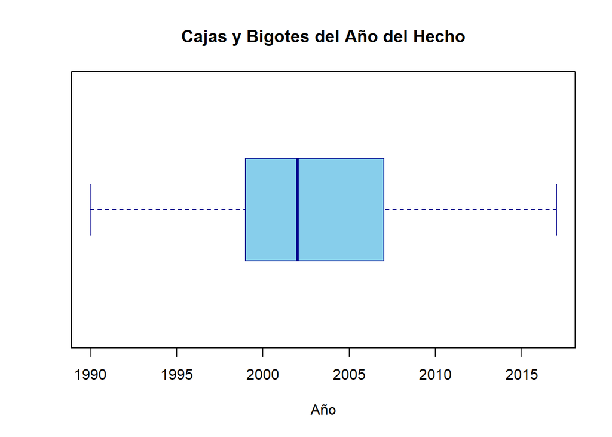

```r
boxplot(
  data$yy_hecho,
  horizontal = TRUE,
  col = "skyblue",
  border = "darkblue",
  main = "Cajas y Bigotes del Año del Hecho",
  xlab = "Año")
```

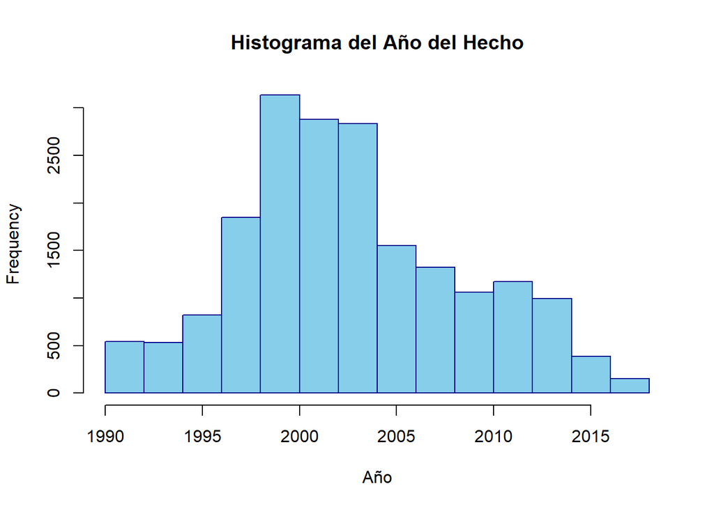

```r
hist(
  data$yy_hecho,
  col = "skyblue",
  border = "darkblue",
  main = "Histograma del Año del Hecho",
  xlab = "Año")
```

### Edad aproximada

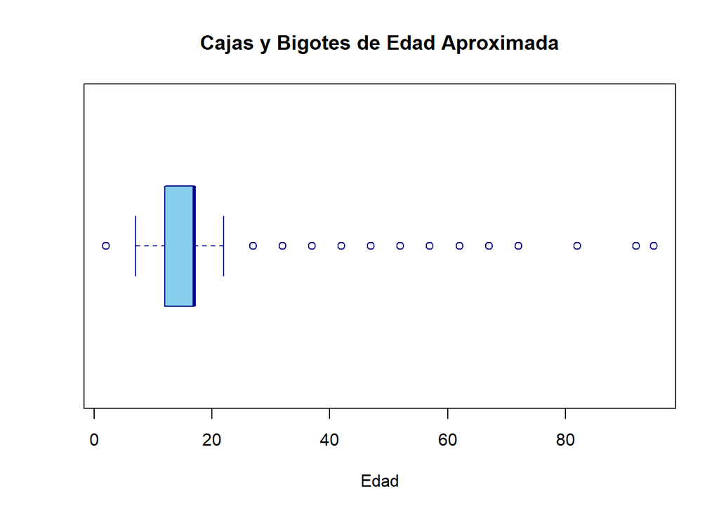

```r
boxplot(
  data$edad_aprox,
  horizontal = TRUE,
  col = "skyblue",
  border = "darkblue",
  main = "Cajas y Bigotes de Edad Aproximada",
  xlab = "Edad")
```

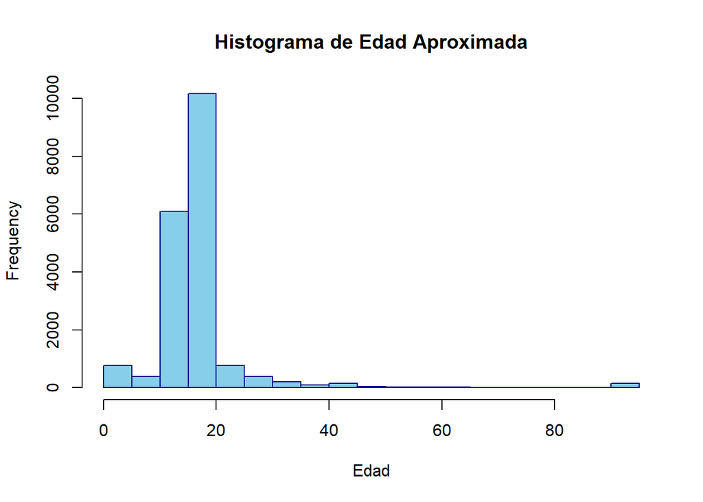

```r
hist(
  data$edad_aprox,
  col = "skyblue",
  border = "darkblue",
  main = "Histograma de Edad Aproximada",
  xlab = "Edad")
```

### Número de fuentes

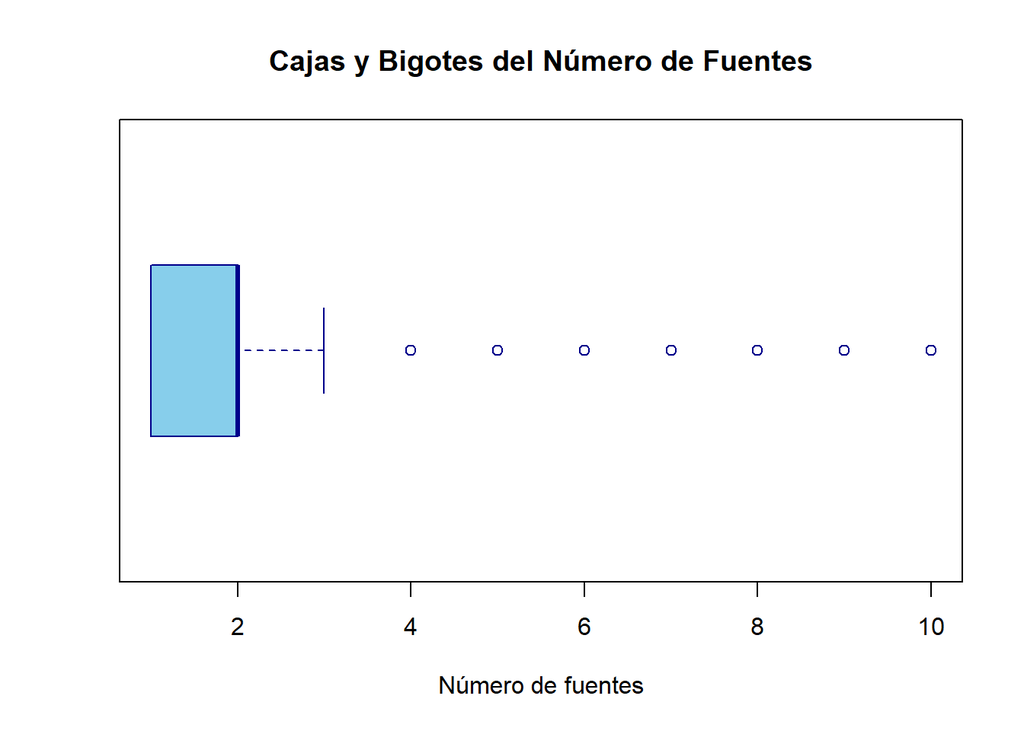

```r
boxplot(
  data$n_fuentes,
  horizontal = TRUE,
  col = "skyblue",
  border = "darkblue",
  main = "Cajas y Bigotes del Número de Fuentes",
  xlab = "Número de fuentes")
```

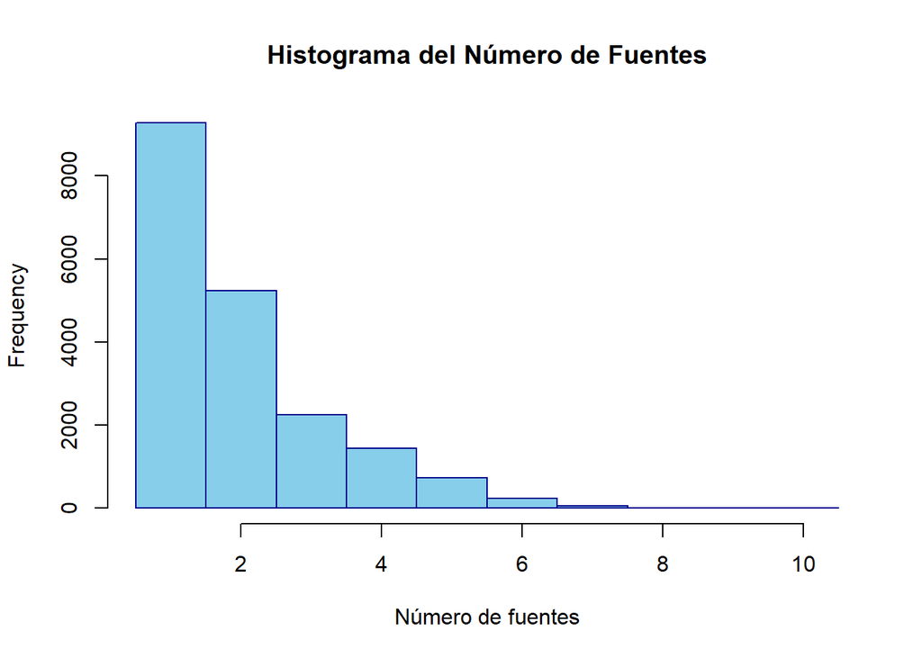

```r
hist(
  data$n_fuentes,
  breaks = seq(0.5, max(data$n_fuentes) + 0.5, by = 1),
  col = "skyblue",
  border = "darkblue",
  main = "Histograma del Número de Fuentes",
  xlab = "Número de fuentes")
```

**El año del hecho se concentra alrededor de 2002 (mediana), con un rango de 1990 a 2017. La edad aproximada presenta una distribución asimétrica a la derecha, con la mayoría de casos entre 10 y 19 años. El número de fuentes por caso tiene mediana de 2 y máximo de 10: la mayoría de casos aparece en una o dos fuentes.**

# 5. Limpieza de datos

## Valores faltantes

Valores perdidos en todo el data frame

```r
# Número total de datos perdidos en el dataframe
total_na <- sum(is.na(data))

print(paste("Total de datos perdidos:", total_na))
```

```
## [1] "Total de datos perdidos: 0"
```

**Total de datos perdidos: 0.** (Esta base ya viene con las variables principales imputadas, como se revisa más abajo.)

Valores faltantes por columnas

```r
# Número de datos perdidos por columna
na_por_columna <- colSums(is.na(data))

# Crear un dataframe con los resultados
tabla_na <- data.frame(
  Columna = names(na_por_columna), # obtiene los nombres de las columnas
  Datos_Perdidos = na_por_columna  # contiene la cantidad de NA por variable
)

# Ordenar de mayor a menor y agregar la fila "Total" al final
tabla_na_ordenada <- tabla_na %>%
  arrange(desc(Datos_Perdidos)) %>%
  rbind(data.frame(Columna = "Total", Datos_Perdidos = total_na))

head(tabla_na_ordenada, 10)
```

```
##                       Columna Datos_Perdidos
## replica               replica              0
## match_group_id match_group_id              0
## in_1                     in_1              0
## in_2                     in_2              0
## in_3                     in_3              0
## in_4                     in_4              0
## in_5                     in_5              0
## in_6                     in_6              0
## in_7                     in_7              0
## in_8                     in_8              0
```

### Valores imputados

Esta base ya trae indicadoras `*_imputed` que señalan qué valores fueron imputados en origen. Es la forma de “dato faltante” que debemos reportar.

```r
vars_imputed <- grep("_imputed$", names(data), value = TRUE)

tabla_imputados <- data.frame(
  Variable = sub("_imputed$", "", vars_imputed),
  Imputados = sapply(data[vars_imputed], sum),
  Porcentaje = round(100 * sapply(data[vars_imputed], mean), 1),
  row.names = NULL
) %>%
  arrange(desc(Imputados))

tabla_imputados
```

```
##          Variable Imputados Porcentaje
## 1           etnia      7509       39.1
## 2           p_str      4352       22.6
## 3            sexo      3561       18.5
## 4  edad_categoria      1851        9.6
## 5        edad_jep      1851        9.6
## 6 muni_code_hecho      1316        6.8
## 7     is_conflict         0        0.0
```

**La variable con mayor proporción de valores imputados es etnia (39.1% de los casos), seguida de p_str (22.6%). Estos valores se conservan, pero deben tenerse presentes al interpretar resultados por etnia, sexo o presunto responsable.**

## TOTAL DATOS DUPLICADOS

```r
sum(duplicated(data))
```

```
## [1] 0
```

**Con todas las columnas, no hay duplicados porque `match_group_id` es único para cada caso.**

```r
length(unique(data$match_group_id)) == nrow(data)
```

```
## [1] TRUE
```

Repetimos la revisión sin considerar las columnas identificadoras (`replica` y `match_group_id`), igual que en clase se excluyó la columna 1 (ID):

```r
cols_id <- c("replica", "match_group_id")

data_sin_id <- data[ , !(names(data) %in% cols_id)]

sum(duplicated(data_sin_id))
```

```
## [1] 618
```

```r
head(data[duplicated(data_sin_id), ])
```

```
##      replica                           match_group_id in_1 in_2 in_3 in_4 in_5
## 251       R3 033c1653c01b523d92b4d0449b00eb1aabffa271    0    0    0    0    0
## 496       R3 06e3f8bc3d9a0c4f485c2d0037a714d11caf5a08    0    0    0    0    0
## 805       R3 0b79a42f246ed721faad5fdaf56b314f6d7c7d65    0    0    0    0    0
## 833       R3 0bfd2f2c976bb4f50f5fb30942fad3e40f003b60    0    0    0    0    0
## 1504      R3 15c824688bc707ac18ffbe0bc34be95621bc82af    0    0    0    0    0
## 1513      R3 15ec60b706680c49a53a9d0cb31491e8d238b03a    0    0    0    0    0
##      in_6 in_7 in_8 in_9 in_10 in_11 in_12 in_13 in_14 in_15 in_16 in_17 in_18
## 251     1    0    0    0     0     0     0     0     0     0     0     0     0
## 496     0    0    0    0     0     0     0     0     0     0     0     0     0
## 805     0    0    0    0     0     0     0     0     0     0     0     0     0
## 833     0    0    0    0     0     0     0     0     0     0     0     0     0
## 1504    1    0    0    0     0     0     0     0     0     0     0     0     0
## 1513    0    0    0    0     0     0     0     0     0     0     0     0     0
##      in_19 in_20 in_21 in_22 in_23 in_24 in_25 in_26 in_27 in_28 in_29 in_30
```

[output cut: 41 more lines]

**Sin contar el identificador hay 618 registros con atributos idénticos (3.2% de la base). Como cada `match_group_id` es único, se interpretan como casos distintos con las mismas características (por ejemplo, mismo sexo, edad, lugar y año) y no como errores de digitación. Por eso, por defecto, no se eliminan (parámetro `ELIMINAR_DUPLICADOS <- FALSE`). Si se cambia a `TRUE`, el código los elimina.**

```r
if (ELIMINAR_DUPLICADOS) {
  data_sin <- data[!duplicated(data_sin_id), ]
} else {
  data_sin <- data
}

dim(data_sin)
```

```
## [1] 19226    57
```

## COMO SE ELIMINAN DATOS PERDIDOS

```r
data_limpia <- na.omit(data_sin)
head(data_limpia)
```

```
##   replica                           match_group_id in_1 in_2 in_3 in_4 in_5
## 1      R3 00052edf411572e2a50685391d81775cec67f186    0    0    0    0    0
## 2      R3 00070241835c406320a12aa1a6dbd8f9bdc30f33    1    0    0    0    0
## 3      R3 00076cb32b97cfa506dc09020980c78b4fca8570    1    0    0    0    0
## 4      R3 0007b2badad2cf9403a3bbef5ef9d59fe2b07e97    1    0    0    0    0
## 5      R3 001db4a364495077b9e9ff13a38e2b8008eff743    0    0    0    0    0
## 6      R3 0025f6385d77feca6cbfa08971cd0c7b56869bab    0    0    0    0    0
##   in_6 in_7 in_8 in_9 in_10 in_11 in_12 in_13 in_14 in_15 in_16 in_17 in_18
## 1    0    0    0    0     0     0     0     0     0     0     0     0     0
## 2    0    0    0    0     0     0     0     0     0     0     0     0     0
## 3    0    0    0    0     0     0     0     0     0     0     0     0     0
## 4    0    0    0    0     0     0     0     0     0     0     0     1     0
## 5    0    0    0    0     0     0     0     0     0     0     0     1     0
## 6    0    0    0    0     0     0     0     0     0     0     0     0     0
##   in_19 in_20 in_21 in_22 in_23 in_24 in_25 in_26 in_27 in_28 in_29 in_30 in_31
```

[output cut: 41 more lines]

```r
dim(data_limpia)
```

```
## [1] 19226    57
```

## DEJAR VARIABLES SOLO CON LA PRIMERA LETRA EN MAYÚSCULA

```r
# Variables cualitativas (se excluyen los identificadores y los códigos)
vars_cualitativas <- c(
  "sexo",
  "etnia",
  "p_str",
  "edad_jep",
  "edad_categoria"
)
```

```r
# Función: minúsculas, sin tildes y solo la primera letra en mayúscula
capitalizar <- function(x) {
  x <- as.character(x)
  x <- tolower(x)
  x <- iconv(x, from = "UTF-8", to = "ASCII//TRANSLIT")
  paste0(
    toupper(substr(x, 1, 1)),
    substr(x, 2, nchar(x))
  )
}

data_limpia[vars_cualitativas] <- lapply(data_limpia[vars_cualitativas], capitalizar)
```

```r
head(data_limpia)
```

```
##   replica                           match_group_id in_1 in_2 in_3 in_4 in_5
## 1      R3 00052edf411572e2a50685391d81775cec67f186    0    0    0    0    0
## 2      R3 00070241835c406320a12aa1a6dbd8f9bdc30f33    1    0    0    0    0
## 3      R3 00076cb32b97cfa506dc09020980c78b4fca8570    1    0    0    0    0
## 4      R3 0007b2badad2cf9403a3bbef5ef9d59fe2b07e97    1    0    0    0    0
## 5      R3 001db4a364495077b9e9ff13a38e2b8008eff743    0    0    0    0    0
## 6      R3 0025f6385d77feca6cbfa08971cd0c7b56869bab    0    0    0    0    0
##   in_6 in_7 in_8 in_9 in_10 in_11 in_12 in_13 in_14 in_15 in_16 in_17 in_18
## 1    0    0    0    0     0     0     0     0     0     0     0     0     0
## 2    0    0    0    0     0     0     0     0     0     0     0     0     0
## 3    0    0    0    0     0     0     0     0     0     0     0     0     0
## 4    0    0    0    0     0     0     0     0     0     0     0     1     0
## 5    0    0    0    0     0     0     0     0     0     0     0     1     0
## 6    0    0    0    0     0     0     0     0     0     0     0     0     0
##   in_19 in_20 in_21 in_22 in_23 in_24 in_25 in_26 in_27 in_28 in_29 in_30 in_31
```

[output cut: 41 more lines]

```r
tabla_Sexo2 <- tabla_freq(data_limpia$sexo, "Sexo")

tabla_Sexo2
```

```
##     Sexo Frecuencia Porcentaje
## 1 Hombre      13423       69.8
## 2  Mujer       5803       30.2
```

```r
tabla_Etnia2 <- tabla_freq(data_limpia$etnia, "Etnia")

tabla_Etnia2
```

```
##      Etnia Frecuencia Porcentaje
## 1  Mestizo      15069       78.4
## 2 Indigena       2268       11.8
## 3     Narp       1880        9.8
## 4      Rom          9        0.0
```

```r
tabla_Responsable2 <- tabla_freq(data_limpia$p_str, "Presunto_Responsable")

tabla_Responsable2
```

```
##   Presunto_Responsable Frecuencia Porcentaje
## 1             Gue-farc      14777       76.9
## 2                 Para       2194       11.4
## 3              Gue-eln       1440        7.5
## 4             Multiple        396        2.1
## 5                 Otro        194        1.0
## 6             Gue-otro        139        0.7
## 7                  Est         86        0.4
```

**Ahora todas las categorías comparten el mismo formato (por ejemplo, “Multiple” ya no se distingue por mayúsculas/minúsculas). Las siglas quedan con solo la primera letra en mayúscula (Narp, Gue-farc, etc.), tal como se aplicó el procedimiento de la clase.**

```r
tabla_Edad_JEP2 <- tabla_freq(data_limpia$edad_jep, "Ciclo_Vida")

tabla_Edad_JEP2
```

```
##     Ciclo_Vida Frecuencia Porcentaje
## 1 Adolescencia       9140       47.5
## 2     Infancia       7248       37.7
## 3      Adultez       2838       14.8
```

## Agrupar presuntos responsables en una nueva columna

Equivalente a unificar casado/casada y soltero/soltera de la clase: aquí agrupamos las tres categorías de guerrilla (GUE-FARC, GUE-ELN y GUE-OTRO) en una sola, y damos nombre explícito a las demás (supuesto: PARA = paramilitares, EST = agentes del Estado).

```r
data_limpia$p_str_grupo <- case_when(
  tolower(data_limpia$p_str) %in% c("gue-farc", "gue-eln", "gue-otro") ~ "Guerrilla",
  tolower(data_limpia$p_str) == "para"     ~ "Paramilitar",
  tolower(data_limpia$p_str) == "est"      ~ "Agente del Estado",
  tolower(data_limpia$p_str) == "multiple" ~ "Multiple",
  TRUE                                     ~ data_limpia$p_str
)
```

```r
table(data_limpia$p_str_grupo)
```

```
##
## Agente del Estado         Guerrilla          Multiple              Otro
##                86             16356               396               194
##       Paramilitar
##              2194
```

## correcciones de errores o inconsistencias

```r
summary(data_limpia$yy_hecho)
```

```
##    Min. 1st Qu.  Median    Mean 3rd Qu.    Max.
##    1990    1999    2002    2003    2007    2017
```

```r
summary(data_limpia$edad_aprox)
```

```
##    Min. 1st Qu.  Median    Mean 3rd Qu.    Max.
##    2.00   12.00   17.00   16.24   17.00   95.00
```

```r
table(data_limpia$edad_categoria, data_limpia$edad_jep)
```

```
##
##         Adolescencia Adultez Infancia
##   0-4              0       0      762
##   10-14            0       0     6095
##   15-19         9140    1019        0
##   20-24            0     754        0
##   25-29            0     375        0
##   30-34            0     195        0
##   35-39            0      86        0
##   40-44            0     148        0
##   45-49            0      44        0
##   5-9              0       0      391
##   50-54            0      30        0
##   55-59            0      18        0
##   60-64            0      15        0
##   65-69            0       5        0
##   70-74            0       2        0
##   80-84            0       1        0
##   90-94            0      74        0
##   95+              0      72        0
```

**La categoría de edad 15-19 aparece repartida entre Adolescencia y Adultez; esto es coherente con un corte a los 18 años dentro de ese quinquenio y no se considera error.**

```r
# Casos con edad de 90 años o más: implausible para reclutamiento
data_limpia[data_limpia$edad_categoria %in% c("90-94", "95+"), c("match_group_id", "edad_categoria", "edad_jep", "yy_hecho", "p_str", "edad_categoria_imputed")] %>%
  head(10)
```

```
##                                match_group_id edad_categoria edad_jep yy_hecho
## 296  03e149f7e453474112e8f878ea29842b70b1eb4f          90-94  Adultez     1992
## 371  0500e8b5b591ca5c1fe104eec0b3dda71a97dcbd          90-94  Adultez     1993
## 470  0684c046e8b9f5f49693aa093e2e1d3b664a7399            95+  Adultez     1998
## 695  09d2be187112fb27130fb6d7ec682ad11cf2890a          90-94  Adultez     1992
## 842  0c17b31cbc514c3bcb4d6e3732f73cc9844fba0c            95+  Adultez     1997
## 1010 0e51e4dd70a7a362858c37fc7bd24d5602c6f04c            95+  Adultez     1996
## 1105 0fba00bcc281d9e68a74304f143c569070cebbb9            95+  Adultez     1999
## 1224 11746cced56cd020fa120ee5aa87f60d9fa10b12            95+  Adultez     1999
## 1336 136960e82764f80502bb9862b284cea39326a874          90-94  Adultez     1993
## 1846 1ac6918a5c64afa6676e392a011818089bdb3a4f          90-94  Adultez     2000
##         p_str edad_categoria_imputed
## 296  Gue-farc                  FALSE
## 371  Gue-farc                   TRUE
## 470      Para                  FALSE
## 695  Gue-farc                  FALSE
## 842  Gue-farc                  FALSE
## 1010 Gue-farc                  FALSE
## 1105 Gue-farc                  FALSE
## 1224     Para                  FALSE
## 1336 Gue-farc                   TRUE
## 1846 Gue-farc                   TRUE
```

**Se identifican 146 casos con edad de 90 años o más en el momento del hecho. Se consideran inconsistencias (equivalente a la Edad >= 100 de la clase) y se excluyen.**

Resumen de reglas de validación:

```r
anio_actual <- as.numeric(format(Sys.Date(), "%Y"))

inconsistencias <- data.frame(
  anio_invalido         = data_limpia$yy_hecho < 1900 | data_limpia$yy_hecho > anio_actual,
  mes_invalido          = data_limpia$mes_hecho < 1 | data_limpia$mes_hecho > 12,
  fecha_incoherente     = data_limpia$yymm_hecho %/% 100 != data_limpia$yy_hecho,
  muni_incoherente      = data_limpia$muni_code_hecho %/% 1000 != data_limpia$dept_code_hecho,
  edad_90_o_mas         = data_limpia$edad_categoria %in% c("90-94", "95+"),
  edad_sin_equivalencia = is.na(data_limpia$edad_aprox),
  sexo_invalido         = !(data_limpia$sexo %in% c("Hombre", "Mujer"))
)

tabla_inconsistencias <- data.frame(
  Regla = names(inconsistencias),
  Registros = colSums(inconsistencias),
  row.names = NULL
)

tabla_inconsistencias
```

```
##                   Regla Registros
## 1         anio_invalido         0
## 2          mes_invalido         0
## 3     fecha_incoherente         0
## 4      muni_incoherente         0
## 5         edad_90_o_mas       146
## 6 edad_sin_equivalencia         0
## 7         sexo_invalido         0
```

```r
data_sin_errores <- data_limpia[rowSums(inconsistencias) == 0, ]
```

```r
dim(data_sin_errores)
```

```
## [1] 19080    58
```

### Columnas constantes

Una columna con un único valor no aporta información y rompe la estandarización (desviación estándar = 0). Las identificamos y las retiramos.

```r
cols_constantes <- names(data_sin_errores)[
  sapply(data_sin_errores, function(x) length(unique(x)) == 1)
]

cols_constantes
```

```
## [1] "replica"             "in_3"                "in_15"
## [4] "in_22"               "in_25"               "in_26"
## [7] "is_conflict"         "is_conflict_imputed"
```

```r
data_sin_errores <- data_sin_errores[ , !(names(data_sin_errores) %in% cols_constantes)]

dim(data_sin_errores)
```

```
## [1] 19080    50
```

## IDENTIFICACION DE VALORES ATÍPICOS

La detección de datos atípicos (outliers) es un paso fundamental en el análisis exploratorio para identificar observaciones que se desvían significativamente del patrón general de los datos. Estas anomalías pueden surgir por errores de medición, fallos en el registro o representar eventos extremos genuinos dentro de la población estudiada. Identificarlos a tiempo es crucial, ya que su presencia puede distorsionar medidas estadísticas clave como la media y la desviación estándar, además de afectar la validez y el ajuste de los modelos predictivos posteriores.

Para determinar estos valores en R se combinan herramientas visuales con criterios estadísticos objetivos. Gráficamente, el diagrama de caja y bigotes (boxplot) permite observar de inmediato los puntos que sobresalen de los límites esperados. Matemáticamente, el método más utilizado se basa en el Rango Intercuartílico ($IQR = Q_3 - Q_1$): se clasifica como atípica cualquier observación que caiga por debajo de $Q_1 - 1.5 \times IQR$ o por encima de $Q_3 + 1.5 \times IQR$. Este enfoque no paramétrico evita que los valores extremos influyan en el cálculo de los umbrales de detección.

$$\text{Límite inferior} = Q_1 - 1.5
\times IQR \qquad \text{Límite superior} = Q_3 + 1.5 \times
IQR$$

```r
# Función: límites del método IQR
limites_iqr <- function(x) {
  Q1 <- quantile(x, 0.25)
  Q3 <- quantile(x, 0.75)
  IQR_valor <- IQR(x)
  c(inferior = unname(Q1 - 1.5 * IQR_valor),
    superior = unname(Q3 + 1.5 * IQR_valor))
}

# Función: marca TRUE si el valor es atípico
es_atipico <- function(x) {
  lim <- limites_iqr(x)
  x < lim[["inferior"]] | x > lim[["superior"]]
}
```

```r
# Tabla resumen de atípicos por variable
tabla_atipicos <- do.call(rbind, lapply(vars_num, function(v) {
  x <- data_sin_errores[[v]]
  lim <- limites_iqr(x)
  data.frame(
    Variable = v,
    Q1 = unname(quantile(x, 0.25)),
    Q3 = unname(quantile(x, 0.75)),
    IQR = IQR(x),
    Limite_inferior = lim[["inferior"]],
    Limite_superior = lim[["superior"]],
    Atipicos = sum(es_atipico(x)),
    Porcentaje = round(100 * mean(es_atipico(x)), 1)
  )
}))

tabla_atipicos
```

```
##     Variable   Q1   Q3 IQR Limite_inferior Limite_superior Atipicos Porcentaje
## 1   yy_hecho 1999 2007   8          1987.0          2019.0        0        0.0
## 2 edad_aprox   12   17   5             4.5            24.5     1681        8.8
## 3  n_fuentes    1    2   1            -0.5             3.5     2461       12.9
```

```r
# Marcamos los atípicos en columnas lógicas (sin eliminar todavía)
for (v in vars_num) {
  data_sin_errores[[paste0("atipico_", v)]] <- es_atipico(data_sin_errores[[v]])
}

# Ejemplo: casos atípicos en número de fuentes
head(data_sin_errores[data_sin_errores$atipico_n_fuentes, c("match_group_id", "n_fuentes", "p_str_grupo", "yy_hecho")])
```

```
##                              match_group_id n_fuentes p_str_grupo yy_hecho
## 4  0007b2badad2cf9403a3bbef5ef9d59fe2b07e97         4   Guerrilla     2014
## 32 0070b9bf71abf16d00397542b1446ab392e336f5         5   Guerrilla     2000
## 39 00847b037e20804fe5d412288e24e02e668be88b         4 Paramilitar     1999
## 41 00884d4daab27f1a5bdb6f5ebcdba7c395e7ba79         4   Guerrilla     2011
## 42 0089331aebc9a3cf5bf49d7dd7f899cb8a85ff29         4   Guerrilla     2014
## 53 00a403ebe5b831f897d9ce85c635c98e4c862766         5   Guerrilla     2012
```

```r
n_antes_atipicos <- nrow(data_sin_errores)

if (ELIMINAR_ATIPICOS) {
  data_sin_errores <- data_sin_errores[
    rowSums(data_sin_errores[paste0("atipico_", vars_num)]) == 0,
  ]
}

nrow(data_sin_errores)
```

```
## [1] 19080
```

**Análisis descriptivo**

```r
dim(data_sin_errores)
```

```
## [1] 19080    53
```

**Las dimensiones de nuestra tabla**

```r
resumen_num <- function(x) {
  unname(c(mean(x), median(x), sd(x), min(x), max(x),
           quantile(x, probs = 0.25),
           quantile(x, probs = 0.50),
           quantile(x, probs = 0.75)))
}

estadisticos <- data.frame(
  Estadístico = c("Media", "Mediana", "Desviación Estándar", "Mínimo", "Máximo",
                  "Q1 (25%)", "Q2 (50%)", "Q3 (75%)"),
  sapply(data_sin_errores[vars_num], resumen_num),
  row.names = NULL
)

estadisticos
```

```
##           Estadístico    yy_hecho edad_aprox n_fuentes
## 1               Media 2003.173742  15.649895  1.968134
## 2             Mediana 2002.000000  17.000000  2.000000
## 3 Desviación Estándar    5.734463   6.115626  1.243519
## 4              Mínimo 1990.000000   2.000000  1.000000
## 5              Máximo 2017.000000  82.000000 10.000000
## 6            Q1 (25%) 1999.000000  12.000000  1.000000
## 7            Q2 (50%) 2002.000000  17.000000  2.000000
## 8            Q3 (75%) 2007.000000  17.000000  2.000000
```

**Medidas descriptivas de manera ordenada**

Casos por año del hecho:

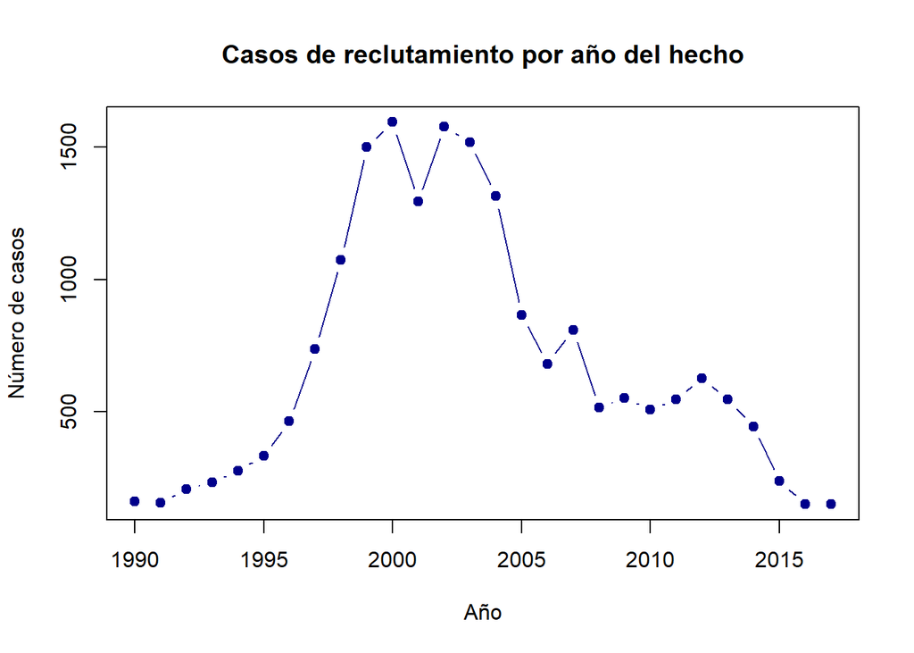

```r
casos_anio <- table(data_sin_errores$yy_hecho)

plot(as.numeric(names(casos_anio)), as.numeric(casos_anio),
     type = "b",
     col = "darkblue",
     pch = 19,
     main = "Casos de reclutamiento por año del hecho",
     xlab = "Año",
     ylab = "Número de casos")
```

```r
anio_pico <- names(casos_anio)[which.max(casos_anio)]
```

**El año con más casos es 2000, con 1595 registros.**

Presunto responsable según sexo (porcentaje por fila):

```r
round(100 * prop.table(table(data_sin_errores$sexo, data_sin_errores$p_str_grupo), margin = 1), 1)
```

```
##
##          Agente del Estado Guerrilla Multiple Otro Paramilitar
##   Hombre               0.4      82.9      2.1  0.9        13.6
##   Mujer                0.4      90.1      2.1  1.1         6.3
```

## ESTANDARIZACION DE VARIABLES

La estandarización de variables (o transformación Z-score) es un método estadístico que permite llevar variables medidas en distintas unidades a una escala común, con media igual a cero y desviación estándar igual a uno.

Matemáticamente, esto se logra aplicando la fórmula $Z = \dfrac{x - \bar{x}}{s}$, donde a cada dato individual ($x$) se le resta el promedio de la variable $\left(\bar{x} = \dfrac{\sum x_i}{n}\right)$ y el resultado se divide entre su desviación estándar muestral $\left(s = \sqrt{\dfrac{\sum (x_i - \bar{x})^2}{n-1}}\right)$. Es la definición que usa la función `scale()` de R (divisor $n-1$). Al realizar este cálculo, cada observación deja de expresarse en su unidad original para indicar cuántas desviaciones estándar se aleja del promedio, sin distorsionar la forma de la distribución.

Este procedimiento es indispensable en la construcción de modelos predictivos, porque evita que las variables con magnitudes numéricas grandes dominen los resultados. Por ejemplo, aquí `yy_hecho` toma valores cercanos a 2000, mientras que `n_fuentes` apenas va de 1 a 10: un algoritmo basado en distancias (K-means, KNN) asumiría erróneamente que el año pesa mucho más. Al aplicar la transformación Z, las variables compiten en igualdad de condiciones.

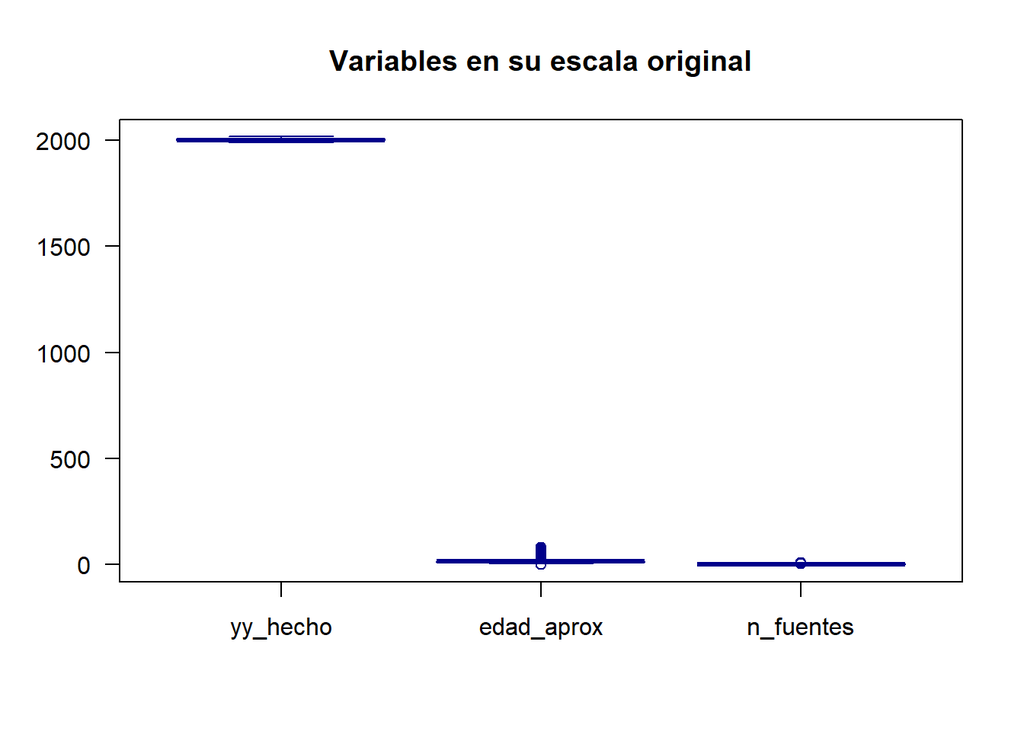

```r
boxplot(
  data_sin_errores[vars_num],
  col = "skyblue",
  border = "darkblue",
  main = "Variables en su escala original",
  las = 1)
```

```r
for (v in vars_num) {
  data_sin_errores[[paste0(v, "_est")]] <- as.numeric(scale(data_sin_errores[[v]]))
}
```

```r
summary(data_sin_errores[paste0(vars_num, "_est")])
```

```
##   yy_hecho_est     edad_aprox_est    n_fuentes_est
##  Min.   :-2.2973   Min.   :-2.2320   Min.   :-0.77854
##  1st Qu.:-0.7278   1st Qu.:-0.5968   1st Qu.:-0.77854
##  Median :-0.2047   Median : 0.2208   Median : 0.02563
##  Mean   : 0.0000   Mean   : 0.0000   Mean   : 0.00000
##  3rd Qu.: 0.6672   3rd Qu.: 0.2208   3rd Qu.: 0.02563
##  Max.   : 2.4111   Max.   :10.8493   Max.   : 6.45898
```

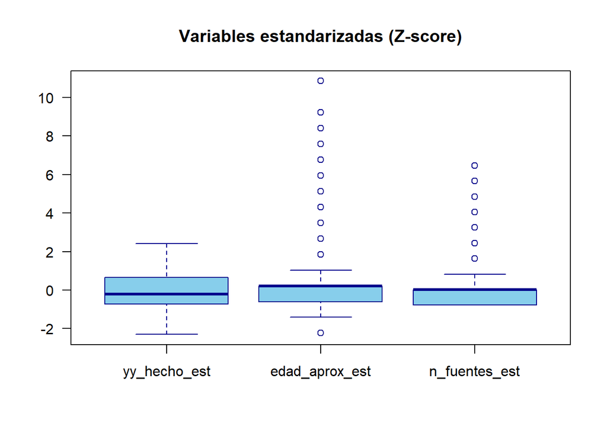

```r
boxplot(
  data_sin_errores[paste0(vars_num, "_est")],
  col = "skyblue",
  border = "darkblue",
  main = "Variables estandarizadas (Z-score)",
  las = 1)
```

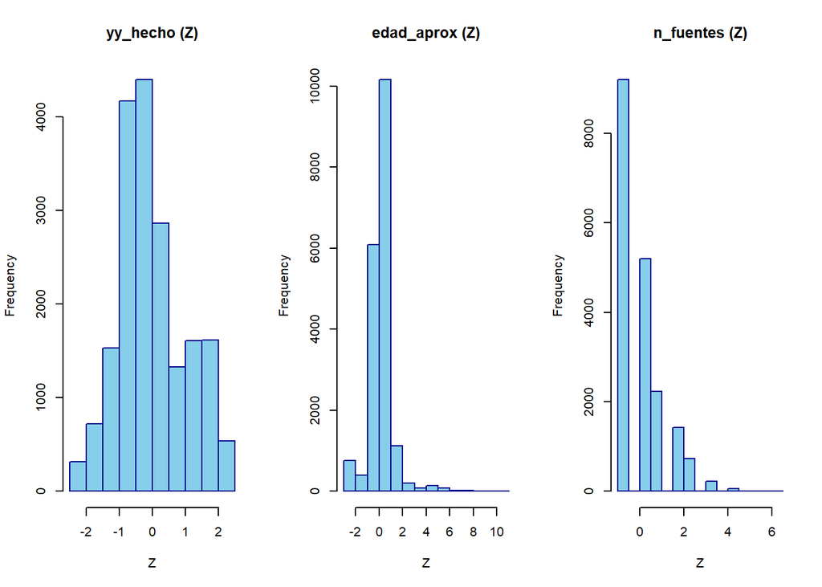

```r
par(mfrow = c(1, 3))

for (v in vars_num) {
  hist(
    data_sin_errores[[paste0(v, "_est")]],
    col = "skyblue",
    border = "darkblue",
    main = paste(v, "(Z)"),
    xlab = "Z")
}
```

```r
par(mfrow = c(1, 1))
```

```r
# Verificación: media ~ 0 y desviación estándar = 1
data.frame(
  Variable = paste0(vars_num, "_est"),
  Media = round(sapply(data_sin_errores[paste0(vars_num, "_est")], mean), 6),
  Desv_Est = sapply(data_sin_errores[paste0(vars_num, "_est")], sd),
  row.names = NULL
)
```

```
##         Variable Media Desv_Est
## 1   yy_hecho_est     0        1
## 2 edad_aprox_est     0        1
## 3  n_fuentes_est     0        1
```

# NORMALIZACION MIN-MAX

La normalización min-max reescala la variable al rango [0, 1]:

$$x_{norm} = \dfrac{x - x_{min}}{x_{max} -
x_{min}}$$

```r
normalizar <- function(x) (x - min(x)) / (max(x) - min(x))

for (v in vars_num) {
  data_sin_errores[[paste0(v, "_norm")]] <- normalizar(data_sin_errores[[v]])
}
```

```r
# Verificación: mínimo y máximo de cada variable normalizada
sapply(data_sin_errores[paste0(vars_num, "_norm")], range)
```

```
##      yy_hecho_norm edad_aprox_norm n_fuentes_norm
## [1,]             0               0              0
## [2,]             1               1              1
```

## Trazabilidad de la limpieza

```r
trazabilidad <- data.frame(
  Etapa = c("Datos originales",
            "Tras duplicados (según parámetro)",
            "Tras eliminar valores perdidos",
            "Tras errores e inconsistencias",
            "Tras atípicos (según parámetro)"),
  Filas = c(nrow(data), nrow(data_sin), nrow(data_limpia),
            n_antes_atipicos, nrow(data_sin_errores))
)

trazabilidad$Filas_Eliminadas <- c(0, -diff(trazabilidad$Filas))

trazabilidad
```

```
##                               Etapa Filas Filas_Eliminadas
## 1                  Datos originales 19226                0
## 2 Tras duplicados (según parámetro) 19226                0
## 3    Tras eliminar valores perdidos 19226                0
## 4    Tras errores e inconsistencias 19080              146
## 5   Tras atípicos (según parámetro) 19080                0
```

# EXPORTAR DATOS

```r
dir.create("../Resultados", showWarnings = FALSE)

write_xlsx(data_sin_errores, "../Resultados/data_final_reclutamiento.xlsx")
```

**Se exportó la base final con 19080 filas y 59 columnas, incluyendo las variables estandarizadas (`_est`), normalizadas (`_norm`) y las marcas de atípicos (`atipico_*`).**